# Prediction of Interest Rate

Yang Liu, Xinmin Wang, Jonathan Jonker

March 10, 2017

## Data cleaning and save new data

#### Delete incomplete cases (32 cases out of 42538 cases)

#### Add GDP growth rate according to the year of loan application

#### Delete cases which home ownership = OTHER or NONE (199 cases out of 42506)

#### Save new data (42307 obs)

## Load data

```
##     int_rate       loan_amnt             term        home_ownership
##  Min.   : 5.42   Min.   :  500    36 months:31311   MORTGAGE:18938
##  1st Qu.: 9.62   1st Qu.: 5200    60 months:10996   OWN     : 3243
##  Median :11.99   Median : 9800                      RENT    :20126
##  Mean   :12.16   Mean   :11108
##  3rd Qu.:14.72   3rd Qu.:15000
##  Max.   :24.59   Max.   :35000
##    annual_inc           dti         delinq_2yrs      fico_range_low
##  Min.   :   1896   Min.   : 0.00   Min.   : 0.0000   Min.   :610.0
##  1st Qu.:  40000   1st Qu.: 8.21   1st Qu.: 0.0000   1st Qu.:685.0
##  Median :  59000   Median :13.49   Median : 0.0000   Median :710.0
##  Mean   :  69170   Mean   :13.38   Mean   : 0.1519   Mean   :713.1
##  3rd Qu.:  82500   3rd Qu.:18.69   3rd Qu.: 0.0000   3rd Qu.:740.0
##  Max.   :6000000   Max.   :29.99   Max.   :13.0000   Max.   :825.0
##     open_acc        revol_util          gdp
##  Min.   : 1.000   Min.   :  0.00   Min.   :-0.00920
##  1st Qu.: 6.000   1st Qu.: 25.70   1st Qu.: 0.03640
##  Median : 9.000   Median : 49.70   Median : 0.03640
##  Mean   : 9.352   Mean   : 49.13   Mean   : 0.03238
##  3rd Qu.:12.000   3rd Qu.: 72.70   3rd Qu.: 0.04560
##  Max.   :47.000   Max.   :119.00   Max.   : 0.04560
```

## Check Intitial Model (all variables, no transformation)

```r
int.model<-lm(int_rate~.,data = loandata)
summary(int.model)
```

```
##
## Call:
## lm(formula = int_rate ~ ., data = loandata)
##
## Residuals:
##      Min       1Q   Median       3Q      Max
## -11.3796  -1.2201  -0.0772   1.0452  12.6416
##
## Coefficients:
##                      Estimate Std. Error  t value Pr(>|t|)
## (Intercept)         6.382e+01  2.426e-01  263.128  < 2e-16 ***
## loan_amnt           1.402e-04  1.377e-06  101.877  < 2e-16 ***
## term 60 months      3.037e+00  2.236e-02  135.827  < 2e-16 ***
## home_ownershipOWN   3.353e-01  3.497e-02    9.589  < 2e-16 ***
## home_ownershipRENT  1.220e-01  1.959e-02    6.230 4.72e-10 ***
## annual_inc          1.280e-07  1.497e-07    0.855    0.393
## dti                -3.395e-02  1.490e-03  -22.791  < 2e-16 ***
## delinq_2yrs         3.502e-02  1.818e-02    1.927    0.054 .
## fico_range_low     -7.425e-02  3.185e-04 -233.160  < 2e-16 ***
## open_acc           -2.906e-02  2.224e-03  -13.066  < 2e-16 ***
## revol_util          5.096e-03  4.044e-04   12.600  < 2e-16 ***
## gdp                -2.119e+01  5.506e-01  -38.490  < 2e-16 ***
## ---
## Signif. codes:  0 '***' 0.001 '**' 0.01 '*' 0.05 '.' 0.1 ' ' 1
##
## Residual standard error: 1.822 on 42295 degrees of freedom
## Multiple R-squared:  0.7588, Adjusted R-squared:  0.7588
## F-statistic: 1.21e+04 on 11 and 42295 DF,  p-value: < 2.2e-16
```

Annual income and delinquency is not significant when controlling for the other variables.

## Stepwise Variable Selection

```r
step(int.model)
```

```
## Start:  AIC=50774.17
## int_rate ~ loan_amnt + term + home_ownership + annual_inc + dti +
##     delinq_2yrs + fico_range_low + open_acc + revol_util + gdp
##
##                  Df Sum of Sq    RSS   AIC
## - annual_inc      1         2 140406 50773
## <none>                        140404 50774
## - delinq_2yrs     1        12 140416 50776
## - home_ownership  2       347 140751 50875
## - revol_util      1       527 140931 50931
## - open_acc        1       567 140970 50943
## - dti             1      1724 142128 51289
## - gdp             1      4918 145322 52229
## - loan_amnt       1     34454 174858 60057
## - term            1     61243 201647 66087
## - fico_range_low  1    180466 320870 85739
##
## Step:  AIC=50772.9
## int_rate ~ loan_amnt + term + home_ownership + dti + delinq_2yrs +
##     fico_range_low + open_acc + revol_util + gdp
##
##                  Df Sum of Sq    RSS   AIC
## <none>                        140406 50773
## - delinq_2yrs     1        13 140419 50775
## - home_ownership  2       345 140751 50873
## - revol_util      1       537 140943 50932
## - open_acc        1       570 140976 50942
## - dti             1      1815 142221 51314
## - gdp             1      4917 145323 52227
## - loan_amnt       1     36557 176963 60561
## - term            1     61397 201804 66118
## - fico_range_low  1    180526 320932 85746
```

```
##
## Call:
## lm(formula = int_rate ~ loan_amnt + term + home_ownership + dti +
##     delinq_2yrs + fico_range_low + open_acc + revol_util + gdp,
##     data = loandata)
##
## Coefficients:
##        (Intercept)           loan_amnt      term 60 months
##          6.383e+01           1.405e-04           3.036e+00
##  home_ownershipOWN  home_ownershipRENT                 dti
##          3.333e-01           1.199e-01          -3.420e-02
##        delinq_2yrs      fico_range_low            open_acc
##          3.548e-02          -7.424e-02          -2.875e-02
##         revol_util                 gdp
##          5.126e-03          -2.119e+01
```

Annual income is excluded later on to reduce sample complexity.

## Check scatterplot matrix

Take a small sample and plot

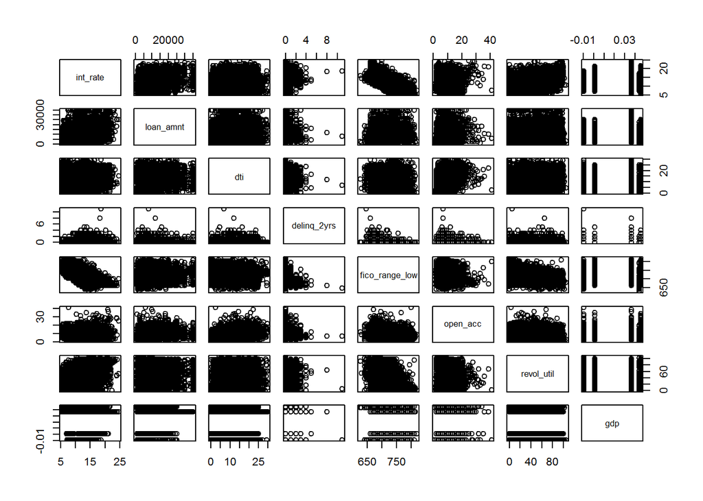

Some variable need to be transformed

## Box-Cox Transformation

```r
tr = powerTransform(cbind(loandata$loan_amnt,loandata$dti+1,loandata$delinq_2yrs+0.1,loandata$fico_range_low,loandata$open_acc,loandata$revol_util+1,loandata$gdp+0.0093)~1)
summary(tr) #(0.25 0.77 -3.46 -2.16 0.25 0.75 1.36)
```

```
## bcPower Transformations to Multinormality
##    Est.Power Std.Err. Wald Lower Bound Wald Upper Bound
## Y1    0.2539   0.0059           0.2424           0.2654
## Y2    0.7739   0.0076           0.7590           0.7889
## Y3   -3.4625   0.0170          -3.4958          -3.4293
## Y4   -2.1559   0.0330          -2.2206          -2.0912
## Y5    0.2543   0.0078           0.2391           0.2695
## Y6    0.7521   0.0053           0.7418           0.7624
## Y7    1.3563   0.0080           1.3406           1.3721
##
## Likelihood ratio tests about transformation parameters
##                                                               LRT df pval
## LR test, lambda = (0 0 0 0 0 0 0)                        228270.7  7    0
## LR test, lambda = (1 1 1 1 1 1 1)                        261734.7  7    0
## LR test, lambda = (0.25 0.77 -3.46 -2.16 0.25 0.75 1.36)      0.0  7    1
```

```r
#test if the lambda c(1,1,-3,-2,0,1,1) we choose is within 95% CI
testTransform(tr,c(1,1,-3,-2,0,1,1))
```

```
##                                          LRT df pval
## LR test, lambda = (1 1 -3 -2 0 1 1) 21224.66  7    0
```

```r
tr.varialbes = as.data.frame(bcPower(cbind(loandata$loan_amnt,loandata$dti+1,loandata$delinq_2yrs+0.1,loandata$fico_range_low,loandata$open_acc,loandata$revol_util+1,loandata$gdp+0.0093),lambda=c(0,1,-3,-2,0,1,1)))
loandata.tr = cbind(loandata$int_rate,tr.varialbes,loandata$term,loandata$home_ownership)
colnames(loandata.tr) = c("int_rate","logloan_amnt","dti_1","tr_delinq_2yrs","fico_range_-2","logopen_acc","revol_util_1","gdp_1","terms","home_ownership")
summary(loandata.tr)
```

```
##     int_rate      logloan_amnt        dti_1       tr_delinq_2yrs
##  Min.   : 5.42   Min.   : 6.215   Min.   : 0.00   Min.   :-333.0000
##  1st Qu.: 9.62   1st Qu.: 8.556   1st Qu.: 8.21   1st Qu.:-333.0000
##  Median :11.99   Median : 9.190   Median :13.49   Median :-333.0000
##  Mean   :12.16   Mean   : 9.075   Mean   :13.38   Mean   :-295.9831
##  3rd Qu.:14.72   3rd Qu.: 9.616   3rd Qu.:18.69   3rd Qu.:-333.0000
##  Max.   :24.59   Max.   :10.463   Max.   :29.99   Max.   :   0.3332
##  fico_range_-2  logopen_acc     revol_util_1        gdp_1
##  Min.   :0.5   Min.   :0.000   Min.   :  0.00   Min.   :-0.9999
##  1st Qu.:0.5   1st Qu.:1.792   1st Qu.: 25.70   1st Qu.:-0.9543
##  Median :0.5   Median :2.197   Median : 49.70   Median :-0.9543
##  Mean   :0.5   Mean   :2.118   Mean   : 49.13   Mean   :-0.9583
##  3rd Qu.:0.5   3rd Qu.:2.485   3rd Qu.: 72.70   3rd Qu.:-0.9451
##  Max.   :0.5   Max.   :3.850   Max.   :119.00   Max.   :-0.9451
##         terms        home_ownership
##   36 months:31311   MORTGAGE:18938
##   60 months:10996   OWN     : 3243
##                     RENT    :20126
##
##
##
```

## Model without transform response variable

```r
md1<-lm(int_rate~.,data = loandata.tr)
summary(md1)# delinquency not significant controlling other variables
```

```
##
## Call:
## lm(formula = int_rate ~ ., data = loandata.tr)
##
## Residuals:
##      Min       1Q   Median       3Q      Max
## -11.8631  -1.2059  -0.0694   1.0355  12.8138
##
## Coefficients:
##                      Estimate Std. Error  t value Pr(>|t|)
## (Intercept)         1.393e+07  5.845e+04  238.382  < 2e-16 ***
## logloan_amnt        1.258e+00  1.335e-02   94.278  < 2e-16 ***
## dti_1              -1.877e-02  1.476e-03  -12.712  < 2e-16 ***
## tr_delinq_2yrs     -1.339e-04  8.896e-05   -1.505    0.132
## `fico_range_-2`    -2.787e+07  1.169e+05 -238.383  < 2e-16 ***
## logopen_acc        -6.927e-01  2.001e-02  -34.614  < 2e-16 ***
## revol_util_1        4.305e-03  3.982e-04   10.810  < 2e-16 ***
## gdp_1              -2.074e+01  5.494e-01  -37.747  < 2e-16 ***
## terms 60 months     3.222e+00  2.200e-02  146.489  < 2e-16 ***
## home_ownershipOWN   1.977e-01  3.485e-02    5.674  1.4e-08 ***
## home_ownershipRENT -2.692e-02  1.941e-02   -1.386    0.166
## ---
## Signif. codes:  0 '***' 0.001 '**' 0.01 '*' 0.05 '.' 0.1 ' ' 1
##
## Residual standard error: 1.817 on 42296 degrees of freedom
## Multiple R-squared:  0.7601, Adjusted R-squared:   0.76
## F-statistic: 1.34e+04 on 10 and 42296 DF,  p-value: < 2.2e-16
```

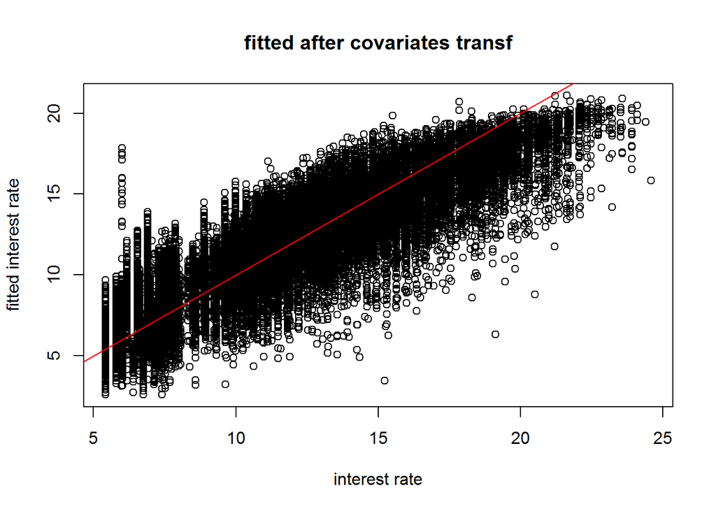

```r
plot(loandata$int_rate,fitted(md1),xlab = "interest rate",ylab = "fitted interest rate",main = "fitted after covariates transf") #some curvature
abline(0,1,col='red')
```

## Transformation on Response

```r
boxcox(md1,plotit=FALSE,lambda = seq(0,1,by=0.1)) #confidence interval does not contain 1.
```

```
## $x
##  [1] 0.0 0.1 0.2 0.3 0.4 0.5 0.6 0.7 0.8 0.9 1.0
##
## $y
##  [1] -147568.2 -147104.1 -146729.2 -146445.0 -146252.5 -146152.3 -146144.5
##  [8] -146228.7 -146403.8 -146668.5 -147020.8
```

```r
md2<-lm(int_rate^0.6~.,data = loandata.tr)
summary(md2)# delinquency still not significant controlling other variables
```

```
##
## Call:
## lm(formula = int_rate^0.6 ~ ., data = loandata.tr)
##
## Residuals:
##      Min       1Q   Median       3Q      Max
## -2.76380 -0.26347 -0.00232  0.23465  2.75533
##
## Coefficients:
##                      Estimate Std. Error  t value Pr(>|t|)
## (Intercept)         3.134e+06  1.290e+04  242.932  < 2e-16 ***
## logloan_amnt        2.801e-01  2.946e-03   95.097  < 2e-16 ***
## dti_1              -3.796e-03  3.258e-04  -11.651  < 2e-16 ***
## tr_delinq_2yrs     -3.621e-05  1.964e-05   -1.844   0.0651 .
## `fico_range_-2`    -6.268e+06  2.580e+04 -242.932  < 2e-16 ***
## logopen_acc        -1.609e-01  4.417e-03  -36.436  < 2e-16 ***
## revol_util_1        9.772e-04  8.789e-05   11.119  < 2e-16 ***
## gdp_1              -5.114e+00  1.212e-01  -42.179  < 2e-16 ***
## terms 60 months     7.047e-01  4.855e-03  145.152  < 2e-16 ***
## home_ownershipOWN   4.504e-02  7.691e-03    5.856 4.77e-09 ***
## home_ownershipRENT -1.572e-03  4.285e-03   -0.367   0.7136
## ---
## Signif. codes:  0 '***' 0.001 '**' 0.01 '*' 0.05 '.' 0.1 ' ' 1
##
## Residual standard error: 0.4011 on 42296 degrees of freedom
## Multiple R-squared:  0.7649, Adjusted R-squared:  0.7649
## F-statistic: 1.376e+04 on 10 and 42296 DF,  p-value: < 2.2e-16
```

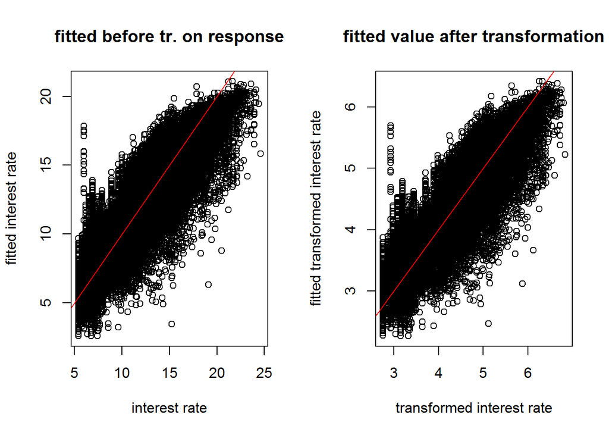

```r
par(mfrow=c(1,2))#compare two plots
plot(loandata$int_rate,fitted(md1),xlab = "interest rate",ylab = "fitted interest rate",main = "fitted before tr. on response") #some curvature
abline(0,1,col='red')
plot(loandata.tr$int_rate^0.6,fitted(md2),xlab = "transformed interest rate",ylab = "fitted transformed interest rate",main = "fitted value after transformation") #better after transformation
abline(0,1,col='red')
```

For prediction purposes, we pick the best value of $\lambda$ compare to models with nontransformed int_rate,variance look more normal after transformation.

## remove delinquency in our model

```r
md3<-lm(int_rate^0.6~.-tr_delinq_2yrs, data = loandata.tr)
summary(md3)
```

```
##
## Call:
## lm(formula = int_rate^0.6 ~ . - tr_delinq_2yrs, data = loandata.tr)
##
## Residuals:
##      Min       1Q   Median       3Q      Max
## -2.76107 -0.26320 -0.00259  0.23457  2.75484
##
## Coefficients:
##                      Estimate Std. Error  t value Pr(>|t|)
## (Intercept)         3.126e+06  1.226e+04  254.906  < 2e-16 ***
## logloan_amnt        2.800e-01  2.945e-03   95.079  < 2e-16 ***
## dti_1              -3.775e-03  3.256e-04  -11.593  < 2e-16 ***
## `fico_range_-2`    -6.253e+06  2.453e+04 -254.906  < 2e-16 ***
## logopen_acc        -1.608e-01  4.416e-03  -36.407  < 2e-16 ***
## revol_util_1        1.008e-03  8.629e-05   11.683  < 2e-16 ***
## gdp_1              -5.118e+00  1.212e-01  -42.215  < 2e-16 ***
## terms 60 months     7.046e-01  4.855e-03  145.145  < 2e-16 ***
## home_ownershipOWN   4.526e-02  7.691e-03    5.885 4.02e-09 ***
## home_ownershipRENT -1.072e-03  4.276e-03   -0.251    0.802
## ---
## Signif. codes:  0 '***' 0.001 '**' 0.01 '*' 0.05 '.' 0.1 ' ' 1
##
## Residual standard error: 0.4011 on 42297 degrees of freedom
## Multiple R-squared:  0.7649, Adjusted R-squared:  0.7649
## F-statistic: 1.529e+04 on 9 and 42297 DF,  p-value: < 2.2e-16
```

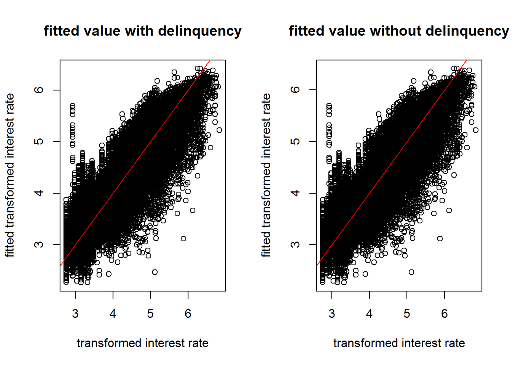

```r
par(mfrow=c(1,2))#compare fitted plots with/without delinquency
plot(loandata.tr$int_rate^0.6,fitted(md2),xlab = "transformed interest rate",ylab = "fitted transformed interest rate",main = "fitted value with delinquency")
abline(0,1,col='red')
plot(loandata.tr$int_rate^0.6,fitted(md3),xlab = "transformed interest rate",ylab = "fitted transformed interest rate",main = "fitted value without delinquency")
abline(0,1,col='red')
```

Removal of delinquency in our model does not change in model coef and p values of other covariates. also the fitted plot does not show a lot difference.